# Churn Modelling

1. Data Preparation and Analysis
2. Model Evaluation and Selection
3. Feature Importance and Reduction

**Goal:** Build a reproducible machine learning model that can predict bank churn.

**Dataset Source:** https://www.kaggle.com/shrutimechlearn/churn-modelling

**Project Repository:** https://github.com/jaredible/CS4300-Project

## Setup

```python
# Import dependencies
import itertools, re, time
import matplotlib.pyplot as plt
import numpy as np
import pandas as pd
import seaborn as sns
import keras.backend as K
from functools import partial

import tensorflow as tf
from tensorflow.keras.utils import plot_model
from tensorflow.keras.models import Sequential
from tensorflow.keras.layers import Dense, Dropout
from tensorflow.keras.callbacks import EarlyStopping, ModelCheckpoint

from sklearn.metrics import confusion_matrix, accuracy_score, precision_score, recall_score, f1_score
```

```python
# Initialize configurations
MAGIC_NUM = 420
np.random.seed(MAGIC_NUM)
np.set_printoptions(formatter = {'float': '{: 0.1f}'.format})
tf.random.set_seed(MAGIC_NUM)
```

```python
# Initialize log directory
log_dir = 'logs'
!rm -rf $log_dir && mkdir $log_dir
```

## Data Preparation and Analysis

### Data Initialization

```python
# Download data
!wget -q https://raw.githubusercontent.com/jaredible/CS4300-Project/master/dataset.csv -O dataset.csv
```

```python
# Load data
df = pd.read_csv('dataset.csv', delimiter = ',')
```

### Exploratory Data Analysis (EDA)

```python
print('# of instances (rows):', df.shape[0])
print('# of features (columns):', df.shape[1])
```

```
# of instances (rows): 10000
# of features (columns): 14
```

```python
# Check for missing data
df.isnull().values.any()
```

```
False
```

```python
# Show data summary
df.info()
```

```
<class 'pandas.core.frame.DataFrame'>
RangeIndex: 10000 entries, 0 to 9999
Data columns (total 14 columns):
 #   Column           Non-Null Count  Dtype
---  ------           --------------  -----
 0   RowNumber        10000 non-null  int64
 1   CustomerId       10000 non-null  int64
 2   Surname          10000 non-null  object
 3   CreditScore      10000 non-null  int64
 4   Geography        10000 non-null  object
 5   Gender           10000 non-null  object
 6   Age              10000 non-null  int64
 7   Tenure           10000 non-null  int64
 8   Balance          10000 non-null  float64
 9   NumOfProducts    10000 non-null  int64
 10  HasCrCard        10000 non-null  int64
 11  IsActiveMember   10000 non-null  int64
 12  EstimatedSalary  10000 non-null  float64
 13  Exited           10000 non-null  int64
dtypes: float64(2), int64(9), object(3)
memory usage: 1.1+ MB
```

### Data Preparation

```python
# Drop possible irrelevant columns
df.drop(columns=['RowNumber', 'CustomerId', 'Surname'], inplace = True, errors = 'ignore')

# Print updated column names
print(*list(df.columns.values), sep = '\n')
```

```
CreditScore
Geography
Gender
Age
Tenure
Balance
NumOfProducts
HasCrCard
IsActiveMember
EstimatedSalary
Exited
```

```python
# One-hot encode data columns

# One-hot encode geography
if 'Geography' in df:
  df = pd.get_dummies(df, columns = ['Geography'])

# One-hot encode gender
if 'Gender' in df:
  df = pd.get_dummies(df, columns = ['Gender'])

# Print updated column names
print(*list(df.columns.values), sep = '\n')
```

```
CreditScore
Age
Tenure
Balance
NumOfProducts
HasCrCard
IsActiveMember
EstimatedSalary
Exited
Geography_France
Geography_Germany
Geography_Spain
Gender_Female
Gender_Male
```

```python
# Rename columns with snake-case convention
df.rename(columns = {'NumOfProducts': 'ProductCount', 'HasCrCard': 'HasCreditCard', 'IsActiveMember': 'Active'}, inplace = True, errors = 'ignore')
df.rename(columns = lambda s: re.sub(r'(?<!^)(?=[A-Z])', '_', s).lower(), inplace = True, errors = 'ignore')

# Print updated column names
print(*list(df.columns.values), sep = '\n')
```

```
credit_score
age
tenure
balance
product_count
has_credit_card
active
estimated_salary
exited
geography__france
geography__germany
geography__spain
gender__female
gender__male
```

```python
# Inspect data
df.head()
```

|  | credit_score | age | tenure | balance | product_count | has_credit_card | active | estimated_salary | exited | geography__france | geography__germany | geography__spain | gender__female | gender__male |
| --- | --- | --- | --- | --- | --- | --- | --- | --- | --- | --- | --- | --- | --- | --- |
| 0 | 619 | 42 | 2 | 0.00 | 1 | 1 | 1 | 101348.88 | 1 | 1 | 0 | 0 | 1 | 0 |
| 1 | 608 | 41 | 1 | 83807.86 | 1 | 0 | 1 | 112542.58 | 0 | 0 | 0 | 1 | 1 | 0 |
| 2 | 502 | 42 | 8 | 159660.80 | 3 | 1 | 0 | 113931.57 | 1 | 1 | 0 | 0 | 1 | 0 |
| 3 | 699 | 39 | 1 | 0.00 | 2 | 0 | 0 | 93826.63 | 0 | 1 | 0 | 0 | 1 | 0 |
| 4 | 850 | 43 | 2 | 125510.82 | 1 | 1 | 1 | 79084.10 | 0 | 0 | 0 | 1 | 1 | 0 |

```python
# Show data statistics
df.describe()
```

|  | credit_score | age | tenure | balance | product_count | has_credit_card | active | estimated_salary | exited | geography__france | geography__germany | geography__spain | gender__female | gender__male |
| --- | --- | --- | --- | --- | --- | --- | --- | --- | --- | --- | --- | --- | --- | --- |
| count | 10000.000000 | 10000.000000 | 10000.000000 | 10000.000000 | 10000.000000 | 10000.00000 | 10000.000000 | 10000.000000 | 10000.000000 | 10000.000000 | 10000.000000 | 10000.000000 | 10000.000000 | 10000.000000 |
| mean | 650.528800 | 38.921800 | 5.012800 | 76485.889288 | 1.530200 | 0.70550 | 0.515100 | 100090.239881 | 0.203700 | 0.501400 | 0.250900 | 0.247700 | 0.454300 | 0.545700 |
| std | 96.653299 | 10.487806 | 2.892174 | 62397.405202 | 0.581654 | 0.45584 | 0.499797 | 57510.492818 | 0.402769 | 0.500023 | 0.433553 | 0.431698 | 0.497932 | 0.497932 |
| min | 350.000000 | 18.000000 | 0.000000 | 0.000000 | 1.000000 | 0.00000 | 0.000000 | 11.580000 | 0.000000 | 0.000000 | 0.000000 | 0.000000 | 0.000000 | 0.000000 |
| 25% | 584.000000 | 32.000000 | 3.000000 | 0.000000 | 1.000000 | 0.00000 | 0.000000 | 51002.110000 | 0.000000 | 0.000000 | 0.000000 | 0.000000 | 0.000000 | 0.000000 |
| 50% | 652.000000 | 37.000000 | 5.000000 | 97198.540000 | 1.000000 | 1.00000 | 1.000000 | 100193.915000 | 0.000000 | 1.000000 | 0.000000 | 0.000000 | 0.000000 | 1.000000 |
| 75% | 718.000000 | 44.000000 | 7.000000 | 127644.240000 | 2.000000 | 1.00000 | 1.000000 | 149388.247500 | 0.000000 | 1.000000 | 1.000000 | 0.000000 | 1.000000 | 1.000000 |
| max | 850.000000 | 92.000000 | 10.000000 | 250898.090000 | 4.000000 | 1.00000 | 1.000000 | 199992.480000 | 1.000000 | 1.000000 | 1.000000 | 1.000000 | 1.000000 | 1.000000 |

### Data Visualizations

#### Input Visualization

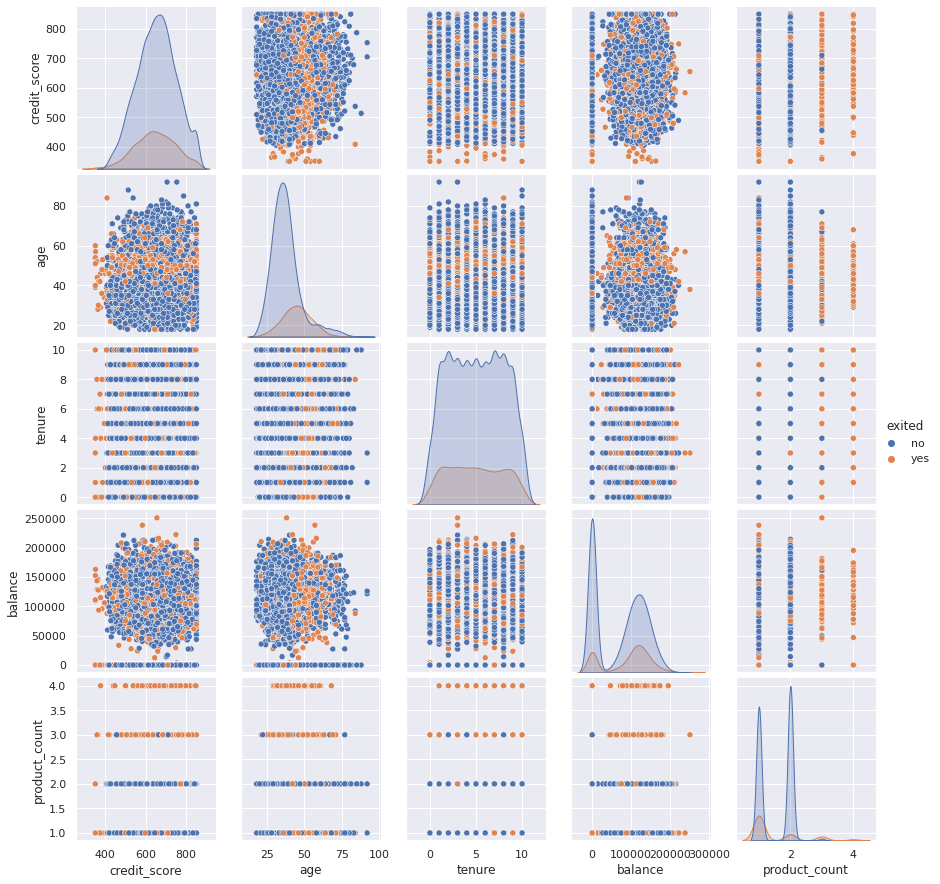

```python
# Visualize correlations between inputs and output
g = sns.pairplot(df[['credit_score', 'age', 'tenure', 'balance', 'product_count', 'exited']], hue = 'exited')
g.legend.get_title().set_text('exited')
g.legend.get_texts()[0].set_text('no')
g.legend.get_texts()[1].set_text('yes')
```

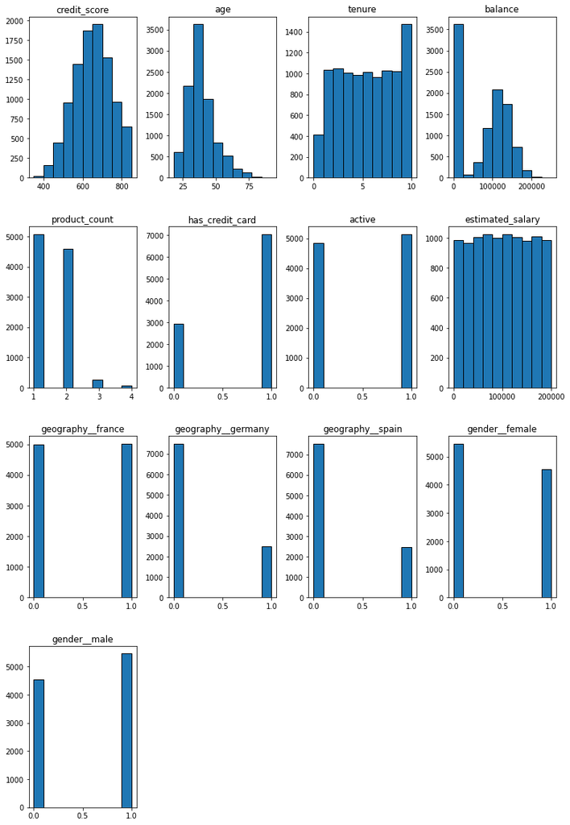

```python
# Visualize input feature distributions
hist = df.drop('exited', axis = 'columns').hist(grid = False, figsize = (13, 20), ec = 'k')
```

#### Output Visualization

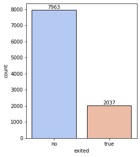

```python
# Visualize output label distribution
plt.figure(figsize = (4, 5))
ax = sns.countplot(x = 'exited', data = df, palette = 'coolwarm', ec = 'k')
xt = plt.xticks([0, 1], ['no', 'true'])
xl = plt.xlabel('exited')
yl = plt.ylabel('count')

# Add count annotations
for rec in ax.patches:
    ax.annotate(format(rec.get_height(), '.0f'), (rec.get_x() + rec.get_width() / 2.0, rec.get_height()), ha = 'center', va = 'center', xytext = (0, 5), textcoords = 'offset points', fontsize = 10)
```

### Data Splitting

#### Data Randomization

By shuffling the data, we ensure that each data point creates an independent change on the model without being biased by the same ones before them.

```python
# Observe data before randomization
df.head()
```

|  | credit_score | age | tenure | balance | product_count | has_credit_card | active | estimated_salary | exited | geography__france | geography__germany | geography__spain | gender__female | gender__male |
| --- | --- | --- | --- | --- | --- | --- | --- | --- | --- | --- | --- | --- | --- | --- |
| 0 | 619 | 42 | 2 | 0.00 | 1 | 1 | 1 | 101348.88 | 1 | 1 | 0 | 0 | 1 | 0 |
| 1 | 608 | 41 | 1 | 83807.86 | 1 | 0 | 1 | 112542.58 | 0 | 0 | 0 | 1 | 1 | 0 |
| 2 | 502 | 42 | 8 | 159660.80 | 3 | 1 | 0 | 113931.57 | 1 | 1 | 0 | 0 | 1 | 0 |
| 3 | 699 | 39 | 1 | 0.00 | 2 | 0 | 0 | 93826.63 | 0 | 1 | 0 | 0 | 1 | 0 |
| 4 | 850 | 43 | 2 | 125510.82 | 1 | 1 | 1 | 79084.10 | 0 | 0 | 0 | 1 | 1 | 0 |

```python
# Shuffle rows
rdf = df.sample(frac = 1, random_state = MAGIC_NUM).reset_index(drop = True)
```

```python
# Observe data after randomization
rdf.head()
```

|  | credit_score | age | tenure | balance | product_count | has_credit_card | active | estimated_salary | exited | geography__france | geography__germany | geography__spain | gender__female | gender__male |
| --- | --- | --- | --- | --- | --- | --- | --- | --- | --- | --- | --- | --- | --- | --- |
| 0 | 850 | 41 | 8 | 132838.07 | 1 | 1 | 1 | 175347.28 | 0 | 0 | 0 | 1 | 0 | 1 |
| 1 | 383 | 48 | 8 | 95808.19 | 1 | 0 | 0 | 137702.01 | 1 | 0 | 0 | 1 | 1 | 0 |
| 2 | 523 | 30 | 1 | 83181.29 | 1 | 1 | 1 | 138176.78 | 0 | 1 | 0 | 0 | 0 | 1 |
| 3 | 435 | 54 | 3 | 0.00 | 1 | 1 | 0 | 156910.46 | 1 | 1 | 0 | 0 | 0 | 1 |
| 4 | 578 | 36 | 8 | 129745.10 | 1 | 1 | 1 | 143683.75 | 0 | 0 | 1 | 0 | 1 | 0 |

#### Development Set Creation

The development set is the data we will use to optimize our model during the development process.

```python
# Convert to Numpy matrix
dataset = rdf.values

# Observe details
print(dataset.shape)
print(dataset)
```

```
(10000, 14)
[[ 850.0  41.0  8.0 ...  1.0  0.0  1.0]
 [ 383.0  48.0  8.0 ...  1.0  1.0  0.0]
 [ 523.0  30.0  1.0 ...  0.0  0.0  1.0]
 ...
 [ 745.0  38.0  5.0 ...  0.0  0.0  1.0]
 [ 616.0  45.0  6.0 ...  0.0  1.0  0.0]
 [ 528.0  35.0  3.0 ...  0.0  0.0  1.0]]
```

```python
# Get input data
X = rdf.drop('exited', axis = 'columns').values

# Observe details
print(X.shape)
print(X)
```

```
(10000, 13)
[[ 850.0  41.0  8.0 ...  1.0  0.0  1.0]
 [ 383.0  48.0  8.0 ...  1.0  1.0  0.0]
 [ 523.0  30.0  1.0 ...  0.0  0.0  1.0]
 ...
 [ 745.0  38.0  5.0 ...  0.0  0.0  1.0]
 [ 616.0  45.0  6.0 ...  0.0  1.0  0.0]
 [ 528.0  35.0  3.0 ...  0.0  0.0  1.0]]
```

```python
# Get output data
Y = rdf['exited'].values

# Observe details
print(Y.shape)
print(Y)
```

```
(10000,)
[0 1 0 ... 0 1 0]
```

```python
# Index for 20%
index = int(0.2 * len(dataset[:, 0]))
print(index)
```

```
2000
```

```python
# Split into training (80%) set
TX = X[index:, :]
TY = Y[index:]

# Observe details
print(TX)
print(TY)
```

```
[[ 650.0  47.0  9.0 ...  0.0  1.0  0.0]
 [ 850.0  50.0  10.0 ...  1.0  1.0  0.0]
 [ 681.0  37.0  7.0 ...  0.0  1.0  0.0]
 ...
 [ 745.0  38.0  5.0 ...  0.0  0.0  1.0]
 [ 616.0  45.0  6.0 ...  0.0  1.0  0.0]
 [ 528.0  35.0  3.0 ...  0.0  0.0  1.0]]
[0 0 0 ... 0 1 0]
```

```python
# Split into validation (20%) set
VX = X[:index, :]
VY = Y[:index]

# Observe details
print(VX)
print(VY)
```

```
[[ 850.0  41.0  8.0 ...  1.0  0.0  1.0]
 [ 383.0  48.0  8.0 ...  1.0  1.0  0.0]
 [ 523.0  30.0  1.0 ...  0.0  0.0  1.0]
 ...
 [ 778.0  34.0  7.0 ...  0.0  1.0  0.0]
 [ 644.0  46.0  6.0 ...  1.0  1.0  0.0]
 [ 640.0  39.0  9.0 ...  0.0  0.0  1.0]]
[0 1 0 ... 0 1 1]
```

### Data Normalization

Normalization aims to change numeric columns' values in the dataset to a standard scale without distorting differences in value ranges.

#### Pre-Normalization

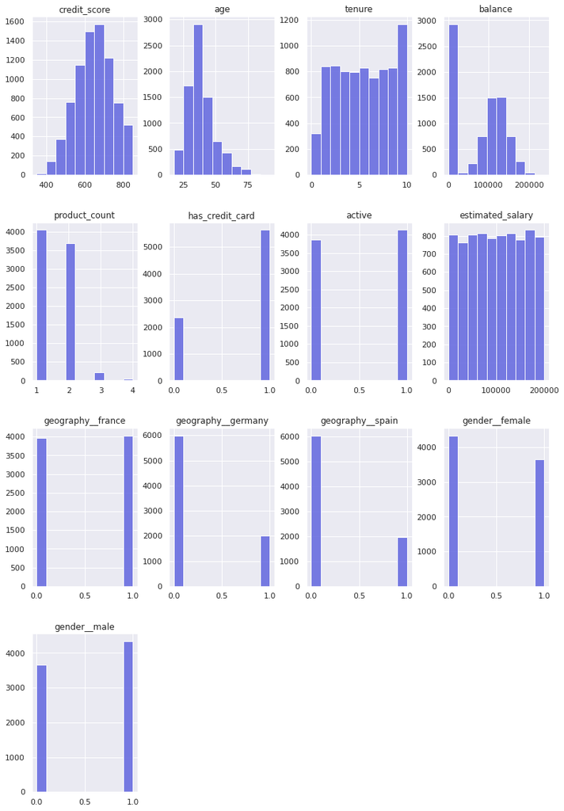

```python
# Visualize input distribution before normalization
dfx = pd.DataFrame(data = TX)
dfx.columns = rdf.drop('exited', axis = 'columns').columns
hist = dfx.hist(figsize = (13, 20), grid = True, bins = 10, color = '#686de0', alpha = 0.9)
```

#### Normalization

```python
# Mean normalization
min = TX.min(axis = 0)
max = TX.max(axis = 0)
mean = TX.mean(axis = 0)
XTRAIN = (TX - mean) / (max - min)
XVALID = (VX - mean) / (max - min)

# Observe details
print(XTRAIN.shape)
print(XTRAIN)
print(XVALID.shape)
print(XVALID)
```

```
(8000, 13)
[[ 0.0  0.1  0.4 ... -0.2  0.5 -0.5]
 [ 0.4  0.1  0.5 ...  0.8  0.5 -0.5]
 [ 0.1 -0.0  0.2 ... -0.2  0.5 -0.5]
 ...
 [ 0.2 -0.0 -0.0 ... -0.2 -0.5  0.5]
 [-0.1  0.1  0.1 ... -0.2  0.5 -0.5]
 [-0.2 -0.1 -0.2 ... -0.2 -0.5  0.5]]
(2000, 13)
[[ 0.4  0.0  0.3 ...  0.8 -0.5  0.5]
 [-0.5  0.1  0.3 ...  0.8  0.5 -0.5]
 [-0.3 -0.1 -0.4 ... -0.2 -0.5  0.5]
 ...
 [ 0.3 -0.1  0.2 ... -0.2  0.5 -0.5]
 [-0.0  0.1  0.1 ...  0.8  0.5 -0.5]
 [-0.0  0.0  0.4 ... -0.2 -0.5  0.5]]
```

```python
# Rescaling
Ymax = TY.max()
YTRAIN = TY / Ymax
YVALID = VY / Ymax

# Observe details
print(YTRAIN.shape)
print(YTRAIN)
print(YVALID.shape)
print(YVALID)
```

```
(8000,)
[ 0.0  0.0  0.0 ...  0.0  1.0  0.0]
(2000,)
[ 0.0  1.0  0.0 ...  0.0  1.0  1.0]
```

#### Post-Normalization

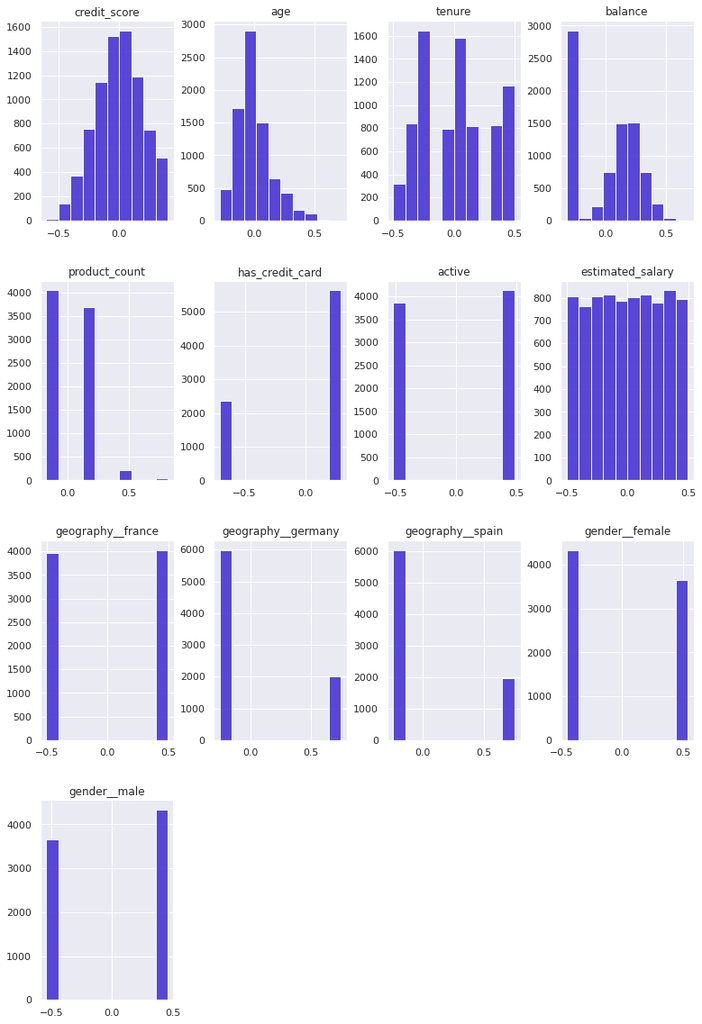

```python
# Visualize input distribution after normalization
dfx = pd.DataFrame(data = XTRAIN)
dfx.columns = rdf.drop('exited', axis = 'columns').columns
hist = dfx.hist(figsize = (13, 20), grid = True, bins = 10, color = '#4834d4', alpha = 0.9)
```

## Model Evaluation and Selection

The goal here is to evaluate multiple models and select the best one that overfits the data. Developing a model, in general, typically has several main steps:

1. Creation (constructing the model)
2. Visualization (showing how the neurons in the model are connected)
3. Compilation (assigning optimization and loss functions for the model)
4. Training (adjusting the weights and biases in the model)
5. Evaluation (checking how well the model correctly classifies the data)

```python
EPOCHS = 2 ** 10
BATCH_SIZE = 2 ** 5
```

### Model Creation

```python
# Baseline model V1
modelBaseline1 = Sequential(name='baseline_1')
modelBaseline1.add(Dense(1, activation = 'relu', input_shape = XTRAIN[0, :].shape))
modelBaseline1.add(Dense(1, activation = 'sigmoid'))
```

```python
# Baseline model V2
modelBaseline2 = Sequential(name='baseline_2')
modelBaseline2.add(Dense(13, activation = 'relu', input_shape = XTRAIN[0, :].shape))
modelBaseline2.add(Dense(1, activation = 'sigmoid'))
```

```python
# Baseline model V3
modelBaseline3 = Sequential(name='baseline_3')
modelBaseline3.add(Dense(13, activation = 'relu', input_shape = XTRAIN[0, :].shape))
modelBaseline3.add(Dense(7, activation = 'relu'))
modelBaseline3.add(Dense(1, activation = 'sigmoid'))
```

```python
# Linear activation model (last neuron)
modelLinearLast = Sequential(name='linear_last')
modelLinearLast.add(Dense(13, activation = 'relu', input_shape = XTRAIN[0, :].shape))
modelLinearLast.add(Dense(7, activation = 'relu'))
modelLinearLast.add(Dense(1, activation = 'linear'))
```

```python
# Linear activation model (all neurons)
modelLinearAll = Sequential(name='linear_all')
modelLinearAll.add(Dense(13, activation = 'linear', input_shape = XTRAIN[0, :].shape))
modelLinearAll.add(Dense(7, activation = 'linear'))
modelLinearAll.add(Dense(1, activation = 'linear'))
```

```python
# Logistic activation model (last neuron)
modelLogisticLast = Sequential(name='logistic_last')
modelLogisticLast.add(Dense(13, activation = 'relu', input_shape = XTRAIN[0, :].shape))
modelLogisticLast.add(Dense(7, activation = 'relu'))
modelLogisticLast.add(Dense(1, activation = 'sigmoid'))
```

```python
# Logistic activation model (all neurons)
modelLogisticAll = Sequential(name='logistic_all')
modelLogisticAll.add(Dense(13, activation = 'sigmoid', input_shape = XTRAIN[0, :].shape))
modelLogisticAll.add(Dense(7, activation = 'sigmoid'))
modelLogisticAll.add(Dense(1, activation = 'sigmoid'))
```

```python
# Overfit model
modelOverfit = Sequential(name='overfit')
modelOverfit.add(Dense(130, activation = 'relu', input_shape = XTRAIN[0, :].shape))
modelOverfit.add(Dense(65, activation = 'relu'))
modelOverfit.add(Dense(1, activation = 'sigmoid'))
```

```python
# Regularized model
modelRegularized = Sequential(name='regularized')
modelRegularized.add(Dense(13, activation = tf.nn.leaky_relu, input_shape = XTRAIN[0, :].shape))
modelRegularized.add(Dropout(0.2))
modelRegularized.add(Dense(26, activation = tf.nn.leaky_relu))
modelRegularized.add(Dropout(0.2))
modelRegularized.add(Dense(13, activation = tf.nn.leaky_relu))
modelRegularized.add(Dropout(0.2))
modelRegularized.add(Dense(1, activation = 'sigmoid'))
```

### Model Visualization

Visualizing our models helps us see how their constructed.

```python
def model_show(model):
  print(model.summary())
  plot_model(model, to_file = f"{log_dir}/{model.name}.png")
```

```python
model_show(modelBaseline1)
```

```
Model: "baseline_1"
_________________________________________________________________
Layer (type)                 Output Shape              Param #
=================================================================
dense (Dense)                (None, 1)                 14
_________________________________________________________________
dense_1 (Dense)              (None, 1)                 2
=================================================================
Total params: 16
Trainable params: 16
Non-trainable params: 0
_________________________________________________________________
None
```

```python
model_show(modelBaseline2)
```

```
Model: "baseline_2"
_________________________________________________________________
Layer (type)                 Output Shape              Param #
=================================================================
dense_2 (Dense)              (None, 13)                182
_________________________________________________________________
dense_3 (Dense)              (None, 1)                 14
=================================================================
Total params: 196
Trainable params: 196
Non-trainable params: 0
_________________________________________________________________
None
```

```python
model_show(modelBaseline3)
```

```
Model: "baseline_3"
_________________________________________________________________
Layer (type)                 Output Shape              Param #
=================================================================
dense_4 (Dense)              (None, 13)                182
_________________________________________________________________
dense_5 (Dense)              (None, 7)                 98
_________________________________________________________________
dense_6 (Dense)              (None, 1)                 8
=================================================================
Total params: 288
Trainable params: 288
Non-trainable params: 0
_________________________________________________________________
None
```

```python
model_show(modelLinearLast)
```

```
Model: "linear_last"
_________________________________________________________________
Layer (type)                 Output Shape              Param #
=================================================================
dense_7 (Dense)              (None, 13)                182
_________________________________________________________________
dense_8 (Dense)              (None, 7)                 98
_________________________________________________________________
dense_9 (Dense)              (None, 1)                 8
=================================================================
Total params: 288
Trainable params: 288
Non-trainable params: 0
_________________________________________________________________
None
```

```python
model_show(modelLinearAll)
```

```
Model: "linear_all"
_________________________________________________________________
Layer (type)                 Output Shape              Param #
=================================================================
dense_10 (Dense)             (None, 13)                182
_________________________________________________________________
dense_11 (Dense)             (None, 7)                 98
_________________________________________________________________
dense_12 (Dense)             (None, 1)                 8
=================================================================
Total params: 288
Trainable params: 288
Non-trainable params: 0
_________________________________________________________________
None
```

```python
model_show(modelLogisticLast)
```

```
Model: "logistic_last"
_________________________________________________________________
Layer (type)                 Output Shape              Param #
=================================================================
dense_13 (Dense)             (None, 13)                182
_________________________________________________________________
dense_14 (Dense)             (None, 7)                 98
_________________________________________________________________
dense_15 (Dense)             (None, 1)                 8
=================================================================
Total params: 288
Trainable params: 288
Non-trainable params: 0
_________________________________________________________________
None
```

```python
model_show(modelLogisticAll)
```

```
Model: "logistic_all"
_________________________________________________________________
Layer (type)                 Output Shape              Param #
=================================================================
dense_16 (Dense)             (None, 13)                182
_________________________________________________________________
dense_17 (Dense)             (None, 7)                 98
_________________________________________________________________
dense_18 (Dense)             (None, 1)                 8
=================================================================
Total params: 288
Trainable params: 288
Non-trainable params: 0
_________________________________________________________________
None
```

```python
model_show(modelOverfit)
```

```
Model: "overfit"
_________________________________________________________________
Layer (type)                 Output Shape              Param #
=================================================================
dense_19 (Dense)             (None, 130)               1820
_________________________________________________________________
dense_20 (Dense)             (None, 65)                8515
_________________________________________________________________
dense_21 (Dense)             (None, 1)                 66
=================================================================
Total params: 10,401
Trainable params: 10,401
Non-trainable params: 0
_________________________________________________________________
None
```

```python
model_show(modelRegularized)
```

```
Model: "regularized"
_________________________________________________________________
Layer (type)                 Output Shape              Param #
=================================================================
dense_22 (Dense)             (None, 13)                182
_________________________________________________________________
dropout (Dropout)            (None, 13)                0
_________________________________________________________________
dense_23 (Dense)             (None, 26)                364
_________________________________________________________________
dropout_1 (Dropout)          (None, 26)                0
_________________________________________________________________
dense_24 (Dense)             (None, 13)                351
_________________________________________________________________
dropout_2 (Dropout)          (None, 13)                0
_________________________________________________________________
dense_25 (Dense)             (None, 1)                 14
=================================================================
Total params: 911
Trainable params: 911
Non-trainable params: 0
_________________________________________________________________
None
```

### Model Compilation

Compiling is to set the optimizer and loss function for training.

```python
def model_compile(model, optimizer = 'adam', loss = 'binary_crossentropy', metrics = ['acc']):
  model.compile(optimizer = optimizer, loss = loss, metrics = metrics)
```

```python
model_compile(modelBaseline1)
```

```python
model_compile(modelBaseline2)
```

```python
model_compile(modelBaseline3)
```

```python
model_compile(modelLinearLast, loss = 'mse', metrics = ['mae'])
```

```python
model_compile(modelLinearAll, loss = 'mse', metrics = ['mae'])
```

```python
model_compile(modelLogisticLast)
```

```python
model_compile(modelLogisticAll)
```

```python
model_compile(modelOverfit)
```

```python
model_compile(modelRegularized)
```

### Model Training

The goal of training a model is to find a set of weights and biases that have low loss, on average, across all the data.

```python
def model_train(model, train_data = (XTRAIN, YTRAIN), valid_data = (XVALID, YVALID), epochs = EPOCHS, batch_size = BATCH_SIZE, verbose = 1):
  K.clear_session()

  callbacks = []
  callbacks.append(ModelCheckpoint(filepath = f"{log_dir}/{model.name}.h5", monitor = 'val_loss', save_best_only = True, save_weights_only = True, verbose = verbose))
  callbacks.append(EarlyStopping(monitor = 'val_loss', mode = 'min', patience = 30, verbose = verbose))

  start = time.time()
  history = model.fit(train_data[0], train_data[1], validation_data = (valid_data[0], valid_data[1]), epochs = epochs, batch_size = batch_size, verbose = verbose, callbacks = callbacks)
  end = time.time()

  return (history, end - start)
```

```python
historyBaseline1, timeBaseline1 = model_train(modelBaseline1)
```

```
Epoch 00001: val_loss improved from inf to 0.58845, saving model to logs/baseline_1.h5

Epoch 00002: val_loss improved from 0.58845 to 0.53127, saving model to logs/baseline_1.h5

Epoch 00003: val_loss improved from 0.53127 to 0.49628, saving model to logs/baseline_1.h5

Epoch 00004: val_loss improved from 0.49628 to 0.47565, saving model to logs/baseline_1.h5

Epoch 00005: val_loss improved from 0.47565 to 0.46416, saving model to logs/baseline_1.h5

Epoch 00006: val_loss improved from 0.46416 to 0.45696, saving model to logs/baseline_1.h5

Epoch 00007: val_loss improved from 0.45696 to 0.45262, saving model to logs/baseline_1.h5

Epoch 00008: val_loss improved from 0.45262 to 0.44901, saving model to logs/baseline_1.h5

Epoch 00009: val_loss improved from 0.44901 to 0.44587, saving model to logs/baseline_1.h5

Epoch 00010: val_loss improved from 0.44587 to 0.44301, saving model to logs/baseline_1.h5

Epoch 00011: val_loss improved from 0.44301 to 0.44041, saving model to logs/baseline_1.h5

Epoch 00012: val_loss improved from 0.44041 to 0.43808, saving model to logs/baseline_1.h5

Epoch 00013: val_loss improved from 0.43808 to 0.43595, saving model to logs/baseline_1.h5

Epoch 00014: val_loss improved from 0.43595 to 0.43388, saving model to logs/baseline_1.h5

Epoch 00015: val_loss improved from 0.43388 to 0.43199, saving model to logs/baseline_1.h5

Epoch 00016: val_loss improved from 0.43199 to 0.43045, saving model to logs/baseline_1.h5

Epoch 00017: val_loss improved from 0.43045 to 0.42904, saving model to logs/baseline_1.h5

Epoch 00018: val_loss improved from 0.42904 to 0.42805, saving model to logs/baseline_1.h5

Epoch 00019: val_loss improved from 0.42805 to 0.42687, saving model to logs/baseline_1.h5

Epoch 00020: val_loss improved from 0.42687 to 0.42615, saving model to logs/baseline_1.h5

```

[output cut: 75 more lines]

```

Epoch 00059: val_loss did not improve from 0.42255

Epoch 00060: val_loss did not improve from 0.42255

Epoch 00061: val_loss did not improve from 0.42255

Epoch 00062: val_loss did not improve from 0.42255

Epoch 00063: val_loss did not improve from 0.42255

Epoch 00064: val_loss did not improve from 0.42255

Epoch 00065: val_loss did not improve from 0.42255
Epoch 00065: early stopping
```

```python
historyBaseline2, timeBaseline2 = model_train(modelBaseline2)
```

```
Epoch 00001: val_loss improved from inf to 0.47412, saving model to logs/baseline_2.h5

Epoch 00002: val_loss improved from 0.47412 to 0.44762, saving model to logs/baseline_2.h5

Epoch 00003: val_loss improved from 0.44762 to 0.43674, saving model to logs/baseline_2.h5

Epoch 00004: val_loss improved from 0.43674 to 0.42707, saving model to logs/baseline_2.h5

Epoch 00005: val_loss improved from 0.42707 to 0.41826, saving model to logs/baseline_2.h5

Epoch 00006: val_loss improved from 0.41826 to 0.41143, saving model to logs/baseline_2.h5

Epoch 00007: val_loss improved from 0.41143 to 0.40525, saving model to logs/baseline_2.h5

Epoch 00008: val_loss improved from 0.40525 to 0.39975, saving model to logs/baseline_2.h5

Epoch 00009: val_loss improved from 0.39975 to 0.39300, saving model to logs/baseline_2.h5

Epoch 00010: val_loss improved from 0.39300 to 0.38708, saving model to logs/baseline_2.h5

Epoch 00011: val_loss improved from 0.38708 to 0.38160, saving model to logs/baseline_2.h5

Epoch 00012: val_loss improved from 0.38160 to 0.37668, saving model to logs/baseline_2.h5

Epoch 00013: val_loss improved from 0.37668 to 0.37188, saving model to logs/baseline_2.h5

Epoch 00014: val_loss improved from 0.37188 to 0.36718, saving model to logs/baseline_2.h5

Epoch 00015: val_loss improved from 0.36718 to 0.36370, saving model to logs/baseline_2.h5

Epoch 00016: val_loss improved from 0.36370 to 0.35983, saving model to logs/baseline_2.h5

Epoch 00017: val_loss improved from 0.35983 to 0.35779, saving model to logs/baseline_2.h5

Epoch 00018: val_loss improved from 0.35779 to 0.35523, saving model to logs/baseline_2.h5

Epoch 00019: val_loss improved from 0.35523 to 0.35303, saving model to logs/baseline_2.h5

Epoch 00020: val_loss improved from 0.35303 to 0.35126, saving model to logs/baseline_2.h5

```

[output cut: 489 more lines]

```

Epoch 00266: val_loss did not improve from 0.33590

Epoch 00267: val_loss did not improve from 0.33590

Epoch 00268: val_loss did not improve from 0.33590

Epoch 00269: val_loss did not improve from 0.33590

Epoch 00270: val_loss did not improve from 0.33590

Epoch 00271: val_loss did not improve from 0.33590

Epoch 00272: val_loss did not improve from 0.33590
Epoch 00272: early stopping
```

```python
historyBaseline3, timeBaseline3 = model_train(modelBaseline3)
```

```
Epoch 00001: val_loss improved from inf to 0.47727, saving model to logs/baseline_3.h5

Epoch 00002: val_loss improved from 0.47727 to 0.45453, saving model to logs/baseline_3.h5

Epoch 00003: val_loss improved from 0.45453 to 0.43729, saving model to logs/baseline_3.h5

Epoch 00004: val_loss improved from 0.43729 to 0.42118, saving model to logs/baseline_3.h5

Epoch 00005: val_loss improved from 0.42118 to 0.40919, saving model to logs/baseline_3.h5

Epoch 00006: val_loss improved from 0.40919 to 0.40018, saving model to logs/baseline_3.h5

Epoch 00007: val_loss improved from 0.40018 to 0.39021, saving model to logs/baseline_3.h5

Epoch 00008: val_loss improved from 0.39021 to 0.38159, saving model to logs/baseline_3.h5

Epoch 00009: val_loss improved from 0.38159 to 0.37046, saving model to logs/baseline_3.h5

Epoch 00010: val_loss improved from 0.37046 to 0.36326, saving model to logs/baseline_3.h5

Epoch 00011: val_loss improved from 0.36326 to 0.35535, saving model to logs/baseline_3.h5

Epoch 00012: val_loss improved from 0.35535 to 0.35474, saving model to logs/baseline_3.h5

Epoch 00013: val_loss improved from 0.35474 to 0.34726, saving model to logs/baseline_3.h5

Epoch 00014: val_loss improved from 0.34726 to 0.34487, saving model to logs/baseline_3.h5

Epoch 00015: val_loss improved from 0.34487 to 0.34398, saving model to logs/baseline_3.h5

Epoch 00016: val_loss improved from 0.34398 to 0.34033, saving model to logs/baseline_3.h5

Epoch 00017: val_loss did not improve from 0.34033

Epoch 00018: val_loss did not improve from 0.34033

Epoch 00019: val_loss improved from 0.34033 to 0.33968, saving model to logs/baseline_3.h5

Epoch 00020: val_loss improved from 0.33968 to 0.33860, saving model to logs/baseline_3.h5

```

[output cut: 107 more lines]

```

Epoch 00075: val_loss did not improve from 0.33352

Epoch 00076: val_loss did not improve from 0.33352

Epoch 00077: val_loss did not improve from 0.33352

Epoch 00078: val_loss did not improve from 0.33352

Epoch 00079: val_loss did not improve from 0.33352

Epoch 00080: val_loss did not improve from 0.33352

Epoch 00081: val_loss did not improve from 0.33352
Epoch 00081: early stopping
```

```python
historyLinearLast, timeLinearLast = model_train(modelLinearLast)
```

```
Epoch 00001: val_loss improved from inf to 0.14070, saving model to logs/linear_last.h5

Epoch 00002: val_loss improved from 0.14070 to 0.13230, saving model to logs/linear_last.h5

Epoch 00003: val_loss improved from 0.13230 to 0.12779, saving model to logs/linear_last.h5

Epoch 00004: val_loss improved from 0.12779 to 0.12458, saving model to logs/linear_last.h5

Epoch 00005: val_loss improved from 0.12458 to 0.12293, saving model to logs/linear_last.h5

Epoch 00006: val_loss improved from 0.12293 to 0.11902, saving model to logs/linear_last.h5

Epoch 00007: val_loss improved from 0.11902 to 0.11598, saving model to logs/linear_last.h5

Epoch 00008: val_loss improved from 0.11598 to 0.11376, saving model to logs/linear_last.h5

Epoch 00009: val_loss improved from 0.11376 to 0.11199, saving model to logs/linear_last.h5

Epoch 00010: val_loss improved from 0.11199 to 0.11139, saving model to logs/linear_last.h5

Epoch 00011: val_loss improved from 0.11139 to 0.11037, saving model to logs/linear_last.h5

Epoch 00012: val_loss did not improve from 0.11037

Epoch 00013: val_loss improved from 0.11037 to 0.10972, saving model to logs/linear_last.h5

Epoch 00014: val_loss improved from 0.10972 to 0.10925, saving model to logs/linear_last.h5

Epoch 00015: val_loss did not improve from 0.10925

Epoch 00016: val_loss improved from 0.10925 to 0.10862, saving model to logs/linear_last.h5

Epoch 00017: val_loss did not improve from 0.10862

Epoch 00018: val_loss did not improve from 0.10862

Epoch 00019: val_loss improved from 0.10862 to 0.10855, saving model to logs/linear_last.h5

Epoch 00020: val_loss improved from 0.10855 to 0.10843, saving model to logs/linear_last.h5

```

[output cut: 203 more lines]

```

Epoch 00123: val_loss did not improve from 0.10334

Epoch 00124: val_loss did not improve from 0.10334

Epoch 00125: val_loss did not improve from 0.10334

Epoch 00126: val_loss did not improve from 0.10334

Epoch 00127: val_loss did not improve from 0.10334

Epoch 00128: val_loss did not improve from 0.10334

Epoch 00129: val_loss did not improve from 0.10334
Epoch 00129: early stopping
```

```python
historyLinearAll, timeLinearAll = model_train(modelLinearAll)
```

```
Epoch 00001: val_loss improved from inf to 0.14444, saving model to logs/linear_all.h5

Epoch 00002: val_loss improved from 0.14444 to 0.13634, saving model to logs/linear_all.h5

Epoch 00003: val_loss improved from 0.13634 to 0.13607, saving model to logs/linear_all.h5

Epoch 00004: val_loss did not improve from 0.13607

Epoch 00005: val_loss did not improve from 0.13607

Epoch 00006: val_loss did not improve from 0.13607

Epoch 00007: val_loss did not improve from 0.13607

Epoch 00008: val_loss did not improve from 0.13607

Epoch 00009: val_loss improved from 0.13607 to 0.13570, saving model to logs/linear_all.h5

Epoch 00010: val_loss did not improve from 0.13570

Epoch 00011: val_loss did not improve from 0.13570

Epoch 00012: val_loss did not improve from 0.13570

Epoch 00013: val_loss did not improve from 0.13570

Epoch 00014: val_loss did not improve from 0.13570

Epoch 00015: val_loss did not improve from 0.13570

Epoch 00016: val_loss did not improve from 0.13570

Epoch 00017: val_loss did not improve from 0.13570

Epoch 00018: val_loss did not improve from 0.13570

Epoch 00019: val_loss did not improve from 0.13570

Epoch 00020: val_loss did not improve from 0.13570

```

[output cut: 23 more lines]

```

Epoch 00033: val_loss did not improve from 0.13570

Epoch 00034: val_loss did not improve from 0.13570

Epoch 00035: val_loss did not improve from 0.13570

Epoch 00036: val_loss did not improve from 0.13570

Epoch 00037: val_loss did not improve from 0.13570

Epoch 00038: val_loss did not improve from 0.13570

Epoch 00039: val_loss did not improve from 0.13570
Epoch 00039: early stopping
```

```python
historyLogisticLast, timeLogisticLast = model_train(modelLogisticLast)
```

```
Epoch 00001: val_loss improved from inf to 0.46958, saving model to logs/logistic_last.h5

Epoch 00002: val_loss improved from 0.46958 to 0.45557, saving model to logs/logistic_last.h5

Epoch 00003: val_loss improved from 0.45557 to 0.44436, saving model to logs/logistic_last.h5

Epoch 00004: val_loss improved from 0.44436 to 0.43347, saving model to logs/logistic_last.h5

Epoch 00005: val_loss improved from 0.43347 to 0.42455, saving model to logs/logistic_last.h5

Epoch 00006: val_loss improved from 0.42455 to 0.41786, saving model to logs/logistic_last.h5

Epoch 00007: val_loss improved from 0.41786 to 0.41086, saving model to logs/logistic_last.h5

Epoch 00008: val_loss improved from 0.41086 to 0.40501, saving model to logs/logistic_last.h5

Epoch 00009: val_loss improved from 0.40501 to 0.39845, saving model to logs/logistic_last.h5

Epoch 00010: val_loss improved from 0.39845 to 0.39283, saving model to logs/logistic_last.h5

Epoch 00011: val_loss improved from 0.39283 to 0.38746, saving model to logs/logistic_last.h5

Epoch 00012: val_loss improved from 0.38746 to 0.38561, saving model to logs/logistic_last.h5

Epoch 00013: val_loss improved from 0.38561 to 0.37695, saving model to logs/logistic_last.h5

Epoch 00014: val_loss improved from 0.37695 to 0.37108, saving model to logs/logistic_last.h5

Epoch 00015: val_loss improved from 0.37108 to 0.36692, saving model to logs/logistic_last.h5

Epoch 00016: val_loss improved from 0.36692 to 0.36014, saving model to logs/logistic_last.h5

Epoch 00017: val_loss improved from 0.36014 to 0.35744, saving model to logs/logistic_last.h5

Epoch 00018: val_loss improved from 0.35744 to 0.35512, saving model to logs/logistic_last.h5

Epoch 00019: val_loss improved from 0.35512 to 0.35038, saving model to logs/logistic_last.h5

Epoch 00020: val_loss improved from 0.35038 to 0.34683, saving model to logs/logistic_last.h5

```

[output cut: 199 more lines]

```

Epoch 00121: val_loss did not improve from 0.32983

Epoch 00122: val_loss did not improve from 0.32983

Epoch 00123: val_loss did not improve from 0.32983

Epoch 00124: val_loss did not improve from 0.32983

Epoch 00125: val_loss did not improve from 0.32983

Epoch 00126: val_loss did not improve from 0.32983

Epoch 00127: val_loss did not improve from 0.32983
Epoch 00127: early stopping
```

```python
historyLogisticAll, timeLogisticAll = model_train(modelLogisticAll)
```

```
Epoch 00001: val_loss improved from inf to 0.51347, saving model to logs/logistic_all.h5

Epoch 00002: val_loss improved from 0.51347 to 0.48666, saving model to logs/logistic_all.h5

Epoch 00003: val_loss improved from 0.48666 to 0.47964, saving model to logs/logistic_all.h5

Epoch 00004: val_loss improved from 0.47964 to 0.47230, saving model to logs/logistic_all.h5

Epoch 00005: val_loss improved from 0.47230 to 0.46501, saving model to logs/logistic_all.h5

Epoch 00006: val_loss improved from 0.46501 to 0.45875, saving model to logs/logistic_all.h5

Epoch 00007: val_loss improved from 0.45875 to 0.45306, saving model to logs/logistic_all.h5

Epoch 00008: val_loss improved from 0.45306 to 0.44796, saving model to logs/logistic_all.h5

Epoch 00009: val_loss improved from 0.44796 to 0.44340, saving model to logs/logistic_all.h5

Epoch 00010: val_loss improved from 0.44340 to 0.43904, saving model to logs/logistic_all.h5

Epoch 00011: val_loss improved from 0.43904 to 0.43505, saving model to logs/logistic_all.h5

Epoch 00012: val_loss improved from 0.43505 to 0.43251, saving model to logs/logistic_all.h5

Epoch 00013: val_loss improved from 0.43251 to 0.42938, saving model to logs/logistic_all.h5

Epoch 00014: val_loss improved from 0.42938 to 0.42689, saving model to logs/logistic_all.h5

Epoch 00015: val_loss improved from 0.42689 to 0.42589, saving model to logs/logistic_all.h5

Epoch 00016: val_loss improved from 0.42589 to 0.42449, saving model to logs/logistic_all.h5

Epoch 00017: val_loss improved from 0.42449 to 0.42386, saving model to logs/logistic_all.h5

Epoch 00018: val_loss improved from 0.42386 to 0.42377, saving model to logs/logistic_all.h5

Epoch 00019: val_loss improved from 0.42377 to 0.42292, saving model to logs/logistic_all.h5

Epoch 00020: val_loss improved from 0.42292 to 0.42280, saving model to logs/logistic_all.h5

```

[output cut: 779 more lines]

```

Epoch 00411: val_loss did not improve from 0.33589

Epoch 00412: val_loss did not improve from 0.33589

Epoch 00413: val_loss did not improve from 0.33589

Epoch 00414: val_loss did not improve from 0.33589

Epoch 00415: val_loss did not improve from 0.33589

Epoch 00416: val_loss did not improve from 0.33589

Epoch 00417: val_loss did not improve from 0.33589
Epoch 00417: early stopping
```

```python
historyOverfit, timeOverfit = model_train(modelOverfit)
```

```
Epoch 00001: val_loss improved from inf to 0.42097, saving model to logs/overfit.h5

Epoch 00002: val_loss improved from 0.42097 to 0.38907, saving model to logs/overfit.h5

Epoch 00003: val_loss improved from 0.38907 to 0.36184, saving model to logs/overfit.h5

Epoch 00004: val_loss improved from 0.36184 to 0.34979, saving model to logs/overfit.h5

Epoch 00005: val_loss did not improve from 0.34979

Epoch 00006: val_loss improved from 0.34979 to 0.34496, saving model to logs/overfit.h5

Epoch 00007: val_loss improved from 0.34496 to 0.34333, saving model to logs/overfit.h5

Epoch 00008: val_loss improved from 0.34333 to 0.34094, saving model to logs/overfit.h5

Epoch 00009: val_loss did not improve from 0.34094

Epoch 00010: val_loss improved from 0.34094 to 0.33797, saving model to logs/overfit.h5

Epoch 00011: val_loss improved from 0.33797 to 0.33634, saving model to logs/overfit.h5

Epoch 00012: val_loss did not improve from 0.33634

Epoch 00013: val_loss did not improve from 0.33634

Epoch 00014: val_loss did not improve from 0.33634

Epoch 00015: val_loss did not improve from 0.33634

Epoch 00016: val_loss did not improve from 0.33634

Epoch 00017: val_loss improved from 0.33634 to 0.33609, saving model to logs/overfit.h5

Epoch 00018: val_loss did not improve from 0.33609

Epoch 00019: val_loss did not improve from 0.33609

Epoch 00020: val_loss improved from 0.33609 to 0.33492, saving model to logs/overfit.h5

```

[output cut: 55 more lines]

```

Epoch 00049: val_loss did not improve from 0.33453

Epoch 00050: val_loss did not improve from 0.33453

Epoch 00051: val_loss did not improve from 0.33453

Epoch 00052: val_loss did not improve from 0.33453

Epoch 00053: val_loss did not improve from 0.33453

Epoch 00054: val_loss did not improve from 0.33453

Epoch 00055: val_loss did not improve from 0.33453
Epoch 00055: early stopping
```

```python
historyRegularized, timeRegularized = model_train(modelRegularized)
```

```
Epoch 00001: val_loss improved from inf to 0.45522, saving model to logs/regularized.h5

Epoch 00002: val_loss improved from 0.45522 to 0.44052, saving model to logs/regularized.h5

Epoch 00003: val_loss improved from 0.44052 to 0.42894, saving model to logs/regularized.h5

Epoch 00004: val_loss improved from 0.42894 to 0.42052, saving model to logs/regularized.h5

Epoch 00005: val_loss improved from 0.42052 to 0.41615, saving model to logs/regularized.h5

Epoch 00006: val_loss improved from 0.41615 to 0.41244, saving model to logs/regularized.h5

Epoch 00007: val_loss improved from 0.41244 to 0.40492, saving model to logs/regularized.h5

Epoch 00008: val_loss improved from 0.40492 to 0.40141, saving model to logs/regularized.h5

Epoch 00009: val_loss improved from 0.40141 to 0.39405, saving model to logs/regularized.h5

Epoch 00010: val_loss improved from 0.39405 to 0.38837, saving model to logs/regularized.h5

Epoch 00011: val_loss improved from 0.38837 to 0.38067, saving model to logs/regularized.h5

Epoch 00012: val_loss improved from 0.38067 to 0.37456, saving model to logs/regularized.h5

Epoch 00013: val_loss improved from 0.37456 to 0.36845, saving model to logs/regularized.h5

Epoch 00014: val_loss improved from 0.36845 to 0.36358, saving model to logs/regularized.h5

Epoch 00015: val_loss improved from 0.36358 to 0.35993, saving model to logs/regularized.h5

Epoch 00016: val_loss improved from 0.35993 to 0.35818, saving model to logs/regularized.h5

Epoch 00017: val_loss improved from 0.35818 to 0.35801, saving model to logs/regularized.h5

Epoch 00018: val_loss improved from 0.35801 to 0.35480, saving model to logs/regularized.h5

Epoch 00019: val_loss improved from 0.35480 to 0.35220, saving model to logs/regularized.h5

Epoch 00020: val_loss improved from 0.35220 to 0.35041, saving model to logs/regularized.h5

```

[output cut: 249 more lines]

```

Epoch 00146: val_loss did not improve from 0.33285

Epoch 00147: val_loss did not improve from 0.33285

Epoch 00148: val_loss did not improve from 0.33285

Epoch 00149: val_loss did not improve from 0.33285

Epoch 00150: val_loss did not improve from 0.33285

Epoch 00151: val_loss did not improve from 0.33285

Epoch 00152: val_loss did not improve from 0.33285
Epoch 00152: early stopping
```

### Model Evaluation

Evaluation helps to find the best model that represents our data and how well the chosen model will work in the future.

```python
def model_evaluate(model, history, train_data = (XTRAIN, YTRAIN), valid_data = (XVALID, YVALID), accuracy_metrics = ('acc', 'val_acc'), loss_metrics = ('loss', 'val_loss'), legend_location = 0b0000):
  # Show model accuracy and loss metrics
  scores = model.evaluate(valid_data[0], valid_data[1])

  # Get model predictions
  prediction = model.predict(valid_data[0]) > 0.5

  # Show model statistics
  accuracy = accuracy_score(valid_data[1], prediction.round()) * 100.0
  precision = precision_score(valid_data[1], prediction.round(), zero_division = 0) * 100.0
  recall = recall_score(valid_data[1], prediction.round(), zero_division = 0) * 100.0
  f1 = f1_score(valid_data[1], prediction.round(), zero_division = 0) * 100.0
  print(f"Accuracy:  {accuracy:.2f}%")
  print(f"Precision: {precision:.2f}%")
  print(f"Recall:    {recall:.2f}%")
  print(f"F1:        {f1:.2f}%")

  # Show classification correctness
  incorrectly_classified = np.count_nonzero(YVALID.astype(int) != 1 * prediction[:, 0])
  correctly_classified = len(YVALID) - incorrectly_classified
  print(f"# of correctly classified:   {correctly_classified}")
  print(f"# of incorrectly classified: {incorrectly_classified}")

  fig, (ax1, ax2, ax3) = plt.subplots(1, 3, figsize = (12, 4))

  xlocs = ['left', 'right']
  ylocs = ['lower', 'upper']

  # Plot train and validation accuracy
  ax1.plot(history.history[accuracy_metrics[0]])
  ax1.plot(history.history[accuracy_metrics[1]])
  ax1.set(title = f"Model '{model.name}' Accuracy", xlabel = 'Epoch', ylabel = 'Accuracy')
  ax1.legend(['Training data', 'Validation data'], loc = f"{ylocs[1 * bool(legend_location & (1 << (2)))]} {xlocs[1 * bool(legend_location & (1 << (3)))]}")

  # Plot train and validation loss
  ax2.plot(history.history[loss_metrics[0]])
  ax2.plot(history.history[loss_metrics[1]])
  ax2.set(title = f"Model '{model.name}' Loss", xlabel = 'Epoch', ylabel = 'Loss')
  ax2.legend(['Training data', 'Validation data'], loc = f"{ylocs[1 * bool(legend_location & (1 << (0)))]} {xlocs[1 * bool(legend_location & (1 << (1)))]}")

  # Plot actual versus predicted results
  cm = confusion_matrix(valid_data[1], prediction)
  ax = sns.heatmap(cm, annot = True, annot_kws = {'size': 15}, xticklabels = ['No', 'Yes'], yticklabels = ['No', 'Yes'], linewidths = 2, fmt = 'g')
  ax.invert_yaxis()
  ax3.set_xlabel("Predicted")
  ax3.set_ylabel("Actual")

  fig.tight_layout()
  fig.show()

  return (accuracy, precision, recall, f1, correctly_classified, incorrectly_classified)
```

```
Accuracy:  80.55%
Precision: 51.56%
Recall:    29.29%
F1:        37.36%
# of correctly classified:   1611
# of incorrectly classified: 389
```

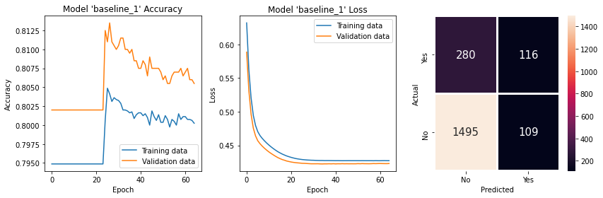

```python
evaluationBaseline1 = model_evaluate(modelBaseline1, historyBaseline1, legend_location = 0b1011)
```

```
Accuracy:  86.10%
Precision: 72.18%
Recall:    48.48%
F1:        58.01%
# of correctly classified:   1722
# of incorrectly classified: 278
```

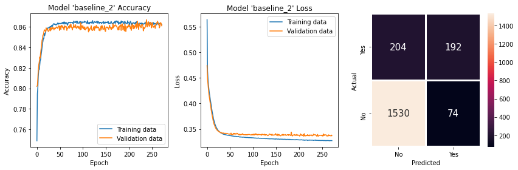

```python
evaluationBaseline2 = model_evaluate(modelBaseline2, historyBaseline2, legend_location = 0b1011)
```

```
Accuracy:  86.00%
Precision: 71.32%
Recall:    48.99%
F1:        58.08%
# of correctly classified:   1720
# of incorrectly classified: 280
```

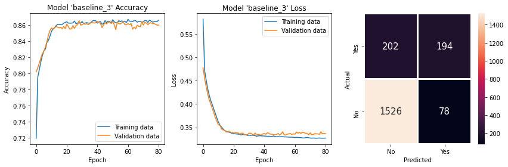

```python
evaluationBaseline3 = model_evaluate(modelBaseline3, historyBaseline3, legend_location = 0b1011)
```

```
Accuracy:  86.20%
Precision: 78.57%
Recall:    41.67%
F1:        54.46%
# of correctly classified:   1724
# of incorrectly classified: 276
```

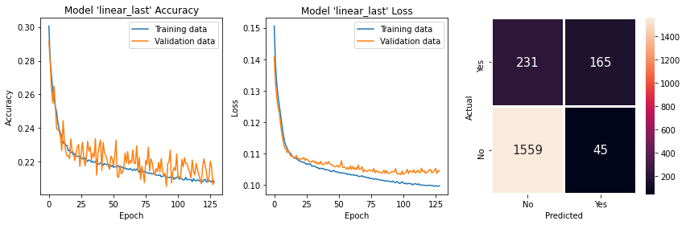

```python
evaluationLinearLast = model_evaluate(modelLinearLast, historyLinearLast, accuracy_metrics = ('mae', 'val_mae'), legend_location = 0b1111)
```

```
Accuracy:  81.20%
Precision: 64.71%
Recall:    11.11%
F1:        18.97%
# of correctly classified:   1624
# of incorrectly classified: 376
```

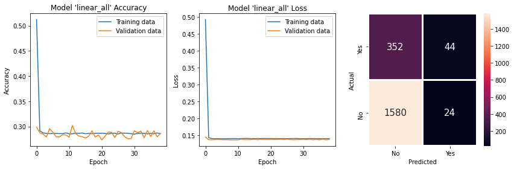

```python
evaluationLinearAll = model_evaluate(modelLinearAll, historyLinearAll, accuracy_metrics = ('mae', 'val_mae'), legend_location = 0b1111)
```

```
Accuracy:  86.65%
Precision: 77.92%
Recall:    45.45%
F1:        57.42%
# of correctly classified:   1733
# of incorrectly classified: 267
```

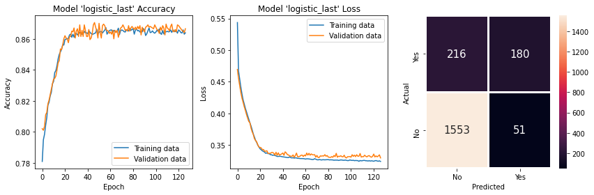

```python
evaluationLogisticLast = model_evaluate(modelLogisticLast, historyLogisticLast, legend_location = 0b1011)
```

```
Accuracy:  86.00%
Precision: 75.00%
Recall:    43.94%
F1:        55.41%
# of correctly classified:   1720
# of incorrectly classified: 280
```

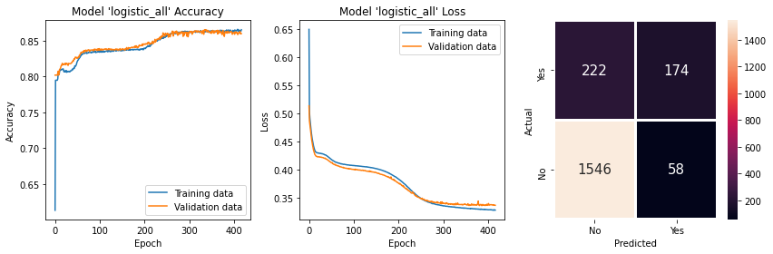

```python
evaluationLogisticAll = model_evaluate(modelLogisticAll, historyLogisticAll, legend_location = 0b1011)
```

```
Accuracy:  84.70%
Precision: 66.19%
Recall:    46.46%
F1:        54.60%
# of correctly classified:   1694
# of incorrectly classified: 306
```

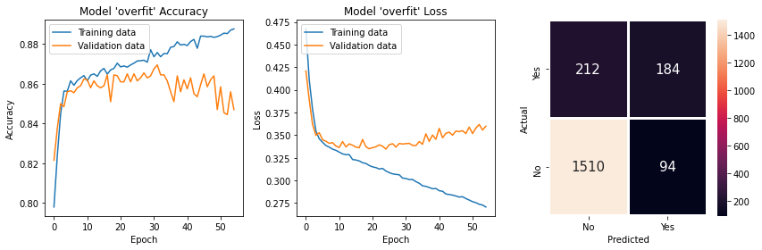

```python
evaluationOverfit = model_evaluate(modelOverfit, historyOverfit, legend_location = 0b0101)
```

```
Accuracy:  86.30%
Precision: 73.83%
Recall:    47.73%
F1:        57.98%
# of correctly classified:   1726
# of incorrectly classified: 274
```

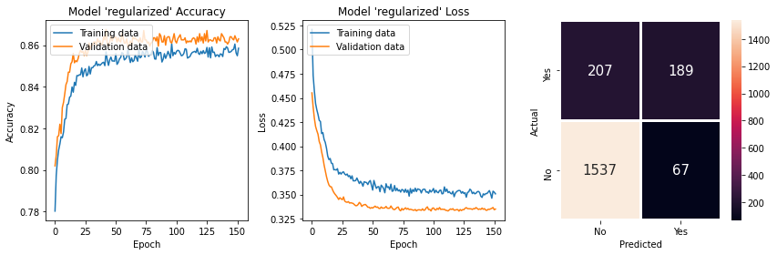

```python
evaluationRegularized = model_evaluate(modelRegularized, historyRegularized, legend_location = 0b0101)
```

## Feature Importance and Reduction

### Feature Importance

```python
feature_importance_accuracies = {}
feature_importance_histories = {}

for column in rdf.drop('exited', axis = 'columns'): #for index in range(dataset.shape[1] - 1):
  print(column)
  x = rdf[column].values
  y = rdf['exited'].values

  # Index for 20%
  index = int(0.2 * len(dataset[:, 0]))

  # Split into training (80%) set
  tx = x[index:]
  ty = y[index:]
  # Split into validation (20%) set
  vx = x[:index]
  vy = y[:index]

  # Mean normalization
  min = tx.min(axis = 0)
  max = tx.max(axis = 0)
  mean = tx.mean(axis = 0)
  tx = (tx - mean) / (max - min)
  vx = (vx - mean) / (max - min)

  # Rescaling
  ym = ty.max()
  ty = ty / ym
  vy = vy / ym

  K.clear_session()

  callbacks = []
  callbacks.append(ModelCheckpoint(filepath = f"feature_importance_{column}.h5", monitor = 'val_loss', save_best_only = True, save_weights_only = True, verbose = 1))
  callbacks.append(EarlyStopping(monitor = 'val_loss', mode = 'min', patience = 30, verbose = 1))

  model = Sequential(name=f"feature_importance_{column}")
  model.add(Dense(130, activation = 'relu', input_dim = 1))
  model.add(Dense(65, activation = 'relu'))
  model.add(Dense(1, activation = 'sigmoid'))
  model.summary()

  model.compile(optimizer = 'adam', loss = 'binary_crossentropy', metrics = ['acc'])
  history = model.fit(tx, ty, validation_data = (vx, vy), epochs = 1024, batch_size = 32, callbacks = callbacks)
  feature_importance_histories[column] = history

  pred = model.predict(vx) > 0.5
  acc = accuracy_score(vy, pred)
  feature_importance_accuracies[column] = acc
  print(acc)
```

```
credit_score
Model: "feature_importance_credit_score"
_________________________________________________________________
Layer (type)                 Output Shape              Param #
=================================================================
dense (Dense)                (None, 130)               260
_________________________________________________________________
dense_1 (Dense)              (None, 65)                8515
_________________________________________________________________
dense_2 (Dense)              (None, 1)                 66
=================================================================
Total params: 8,841
Trainable params: 8,841
Non-trainable params: 0
_________________________________________________________________

Epoch 00001: val_loss improved from inf to 0.49977, saving model to feature_importance_credit_score.h5

Epoch 00002: val_loss improved from 0.49977 to 0.49899, saving model to feature_importance_credit_score.h5

Epoch 00003: val_loss improved from 0.49899 to 0.49831, saving model to feature_importance_credit_score.h5

Epoch 00004: val_loss improved from 0.49831 to 0.49741, saving model to feature_importance_credit_score.h5

Epoch 00005: val_loss did not improve from 0.49741

Epoch 00006: val_loss did not improve from 0.49741

Epoch 00007: val_loss improved from 0.49741 to 0.49691, saving model to feature_importance_credit_score.h5

Epoch 00008: val_loss improved from 0.49691 to 0.49670, saving model to feature_importance_credit_score.h5

Epoch 00009: val_loss did not improve from 0.49670

Epoch 00010: val_loss did not improve from 0.49670

Epoch 00011: val_loss improved from 0.49670 to 0.49663, saving model to feature_importance_credit_score.h5

Epoch 00012: val_loss did not improve from 0.49663

```

[output cut: 1806 more lines]

```
Epoch 00058: val_loss did not improve from 0.49409

Epoch 00059: val_loss did not improve from 0.49409

Epoch 00060: val_loss did not improve from 0.49409

Epoch 00061: val_loss did not improve from 0.49409

Epoch 00062: val_loss did not improve from 0.49409

Epoch 00063: val_loss did not improve from 0.49409

Epoch 00064: val_loss did not improve from 0.49409
Epoch 00064: early stopping
0.802
```

```python
print(feature_importance_accuracies)
```

```
{'credit_score': 0.804, 'age': 0.8075, 'tenure': 0.802, 'balance': 0.802, 'product_count': 0.824, 'has_credit_card': 0.802, 'active': 0.802, 'estimated_salary': 0.802, 'geography__france': 0.802, 'geography__germany': 0.802, 'geography__spain': 0.802, 'gender__female': 0.802, 'gender__male': 0.802}
```

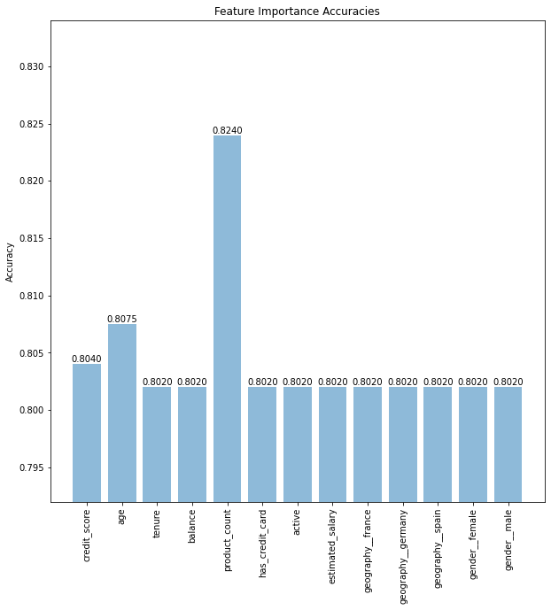

```python
margin = 0.01
h = np.arange(len(feature_importance_accuracies.keys()))
fig, ax = plt.subplots(figsize = (10, 10))
plt.title('Feature Importance Accuracies')
bars = ax.bar(h, feature_importance_accuracies.values(), align = 'center', alpha = 0.5)
plt.xticks(h, feature_importance_accuracies.keys(), fontsize = 10, rotation = 90)
plt.ylabel('Accuracy')
plt.ylim(np.maximum(np.amin(list(feature_importance_accuracies.values())) - margin, 0.0), np.minimum(np.amax(list(feature_importance_accuracies.values())) + margin, 1.0))
for rec in bars.patches:
  ax.annotate(format(rec.get_height(), '.4f'), (rec.get_x() + rec.get_width() / 2.0, rec.get_height()), ha = 'center', va = 'center', xytext = (0, 5), textcoords = 'offset points', fontsize = 10)
plt.show()
```

### Feature Reduction

Starting with all features and removing the least significant iteratively.

```python
tdf = rdf.drop('exited', axis = 'columns')
feature_reduction_accuracies = {}
feature_reduction_histories = {}

# TODO: automate
sorted_feature_importance_accuracies = [
        'product_count',
        'age',
        'credit_score',
        'balance',
        'tenure',
        'has_credit_card',
        'active',
        'estimated_salary',
        'geography__france',
        'geography__germany',
        'geography__spain',
        'gender__female',
        'gender__male'
        ]

for column in sorted_feature_importance_accuracies[::-1]:
  print(column)
  x = tdf.values
  y = rdf['exited'].values

  # Index for 20%
  index = int(0.2 * len(dataset[:, 0]))

  # Split into training (80%) set
  tx = x[index:]
  ty = y[index:]
  # Split into validation (20%) set
  vx = x[:index]
  vy = y[:index]

  print(tx.shape)

  # Mean normalization
  min = tx.min(axis = 0)
  max = tx.max(axis = 0)
  mean = tx.mean(axis = 0)
  tx = (tx - mean) / (max - min)
  vx = (vx - mean) / (max - min)

  # Rescaling
  ym = ty.max()
  ty = ty / ym
  vy = vy / ym

  K.clear_session()

  callbacks = []
  callbacks.append(ModelCheckpoint(filepath = f"feature_reduction_{column}.h5", monitor = 'val_loss', save_best_only = True, save_weights_only = True, verbose = 1))
  callbacks.append(EarlyStopping(monitor = 'val_loss', mode = 'min', patience = 30, verbose = 1))

  model = Sequential(name=f"feature_reduction_{column}")
  model.add(Dense(13, activation = tf.nn.leaky_relu, input_dim = len(tx[0, :])))
  model.add(Dropout(0.2))
  model.add(Dense(26, activation = tf.nn.leaky_relu))
  model.add(Dropout(0.2))
  model.add(Dense(13, activation = tf.nn.leaky_relu))
  model.add(Dropout(0.2))
  model.add(Dense(1, activation = 'sigmoid'))
  model.summary()

  model.compile(optimizer = 'adam', loss = 'binary_crossentropy', metrics = ['acc'])
  history = model.fit(tx, ty, validation_data = (vx, vy), epochs = 1024, batch_size = 32, callbacks = callbacks)
  feature_reduction_histories[column] = history

  pred = model.predict(vx) > 0.5
  acc = accuracy_score(vy, pred)
  feature_reduction_accuracies[column] = acc
  print(acc)

  tdf = tdf.drop(column, axis = 'columns')
```

```
Streaming output truncated to the last 5000 lines.

Epoch 00034: val_loss did not improve from 0.34848

Epoch 00035: val_loss improved from 0.34848 to 0.34728, saving model to feature_reduction_geography__france.h5

Epoch 00036: val_loss did not improve from 0.34728

Epoch 00037: val_loss did not improve from 0.34728

Epoch 00038: val_loss improved from 0.34728 to 0.34639, saving model to feature_reduction_geography__france.h5

Epoch 00039: val_loss did not improve from 0.34639

Epoch 00040: val_loss did not improve from 0.34639

Epoch 00041: val_loss did not improve from 0.34639

Epoch 00042: val_loss did not improve from 0.34639

Epoch 00043: val_loss did not improve from 0.34639

Epoch 00044: val_loss improved from 0.34639 to 0.34597, saving model to feature_reduction_geography__france.h5

Epoch 00045: val_loss did not improve from 0.34597

Epoch 00046: val_loss improved from 0.34597 to 0.34589, saving model to feature_reduction_geography__france.h5

Epoch 00047: val_loss did not improve from 0.34589

Epoch 00048: val_loss improved from 0.34589 to 0.34562, saving model to feature_reduction_geography__france.h5

Epoch 00049: val_loss improved from 0.34562 to 0.34453, saving model to feature_reduction_geography__france.h5

Epoch 00050: val_loss did not improve from 0.34453

Epoch 00051: val_loss did not improve from 0.34453

Epoch 00052: val_loss did not improve from 0.34453

```

[output cut: 2552 more lines]

```
Epoch 00045: val_loss did not improve from 0.43435

Epoch 00046: val_loss did not improve from 0.43435

Epoch 00047: val_loss did not improve from 0.43435

Epoch 00048: val_loss did not improve from 0.43435

Epoch 00049: val_loss did not improve from 0.43435

Epoch 00050: val_loss did not improve from 0.43435

Epoch 00051: val_loss did not improve from 0.43435
Epoch 00051: early stopping
0.824
```

```python
print(feature_reduction_accuracies)
```

```
{'gender__male': 0.8575, 'gender__female': 0.863, 'geography__spain': 0.863, 'geography__germany': 0.862, 'geography__france': 0.859, 'estimated_salary': 0.86, 'active': 0.8565, 'has_credit_card': 0.838, 'tenure': 0.8405, 'balance': 0.8365, 'credit_score': 0.837, 'age': 0.836, 'product_count': 0.824…
```

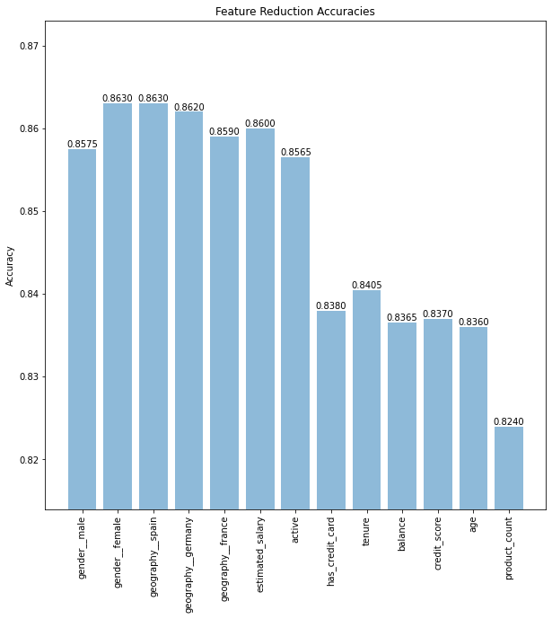

```python
margin = 0.01
h = np.arange(len(feature_reduction_accuracies.keys()))
fig, ax = plt.subplots(figsize = (10, 10))
plt.title('Feature Reduction Accuracies')
bars = ax.bar(h, feature_reduction_accuracies.values(), align = 'center', alpha = 0.5)
plt.xticks(h, feature_reduction_accuracies.keys(), fontsize = 10, rotation = 90)
plt.ylabel('Accuracy')
plt.ylim(np.maximum(np.amin(list(feature_reduction_accuracies.values())) - margin, 0.0), np.minimum(np.amax(list(feature_reduction_accuracies.values())) + margin, 1.0))
for rec in bars.patches:
  ax.annotate(format(rec.get_height(), '.4f'), (rec.get_x() + rec.get_width() / 2.0, rec.get_height()), ha = 'center', va = 'center', xytext = (0, 5), textcoords = 'offset points', fontsize = 10)
plt.show()
```